# Tercer taller Series de tiempo

Juan Pablo Jaramillo C

2/12/2020

##### a) Realice el ajuste sin considerar las ultimas 8 observaciones de la serie correspondiente. Estas ultimas observaciones se dejarán y serán utilizadas para evaluar la calidad de pronóstico de dicho modelo.

Para evaluar la calidad del pronostico se trabajará con la base de datos “We_03_W5.csv” donde tenemos una tasa anual de muertes de cáncer de una ciudad determinada. Para apreciar mejor el trabajo, las librerías se cargaron previamente , esto con el fin de una mejor apariencia.

Esta serie no es estacionario, observemos el siguiente gráfico

[interactive chart not shown]

Haciendo una diferenciación de la series obtenemos.

[interactive chart not shown]

Observemos también las gráficas ACF y PACF.

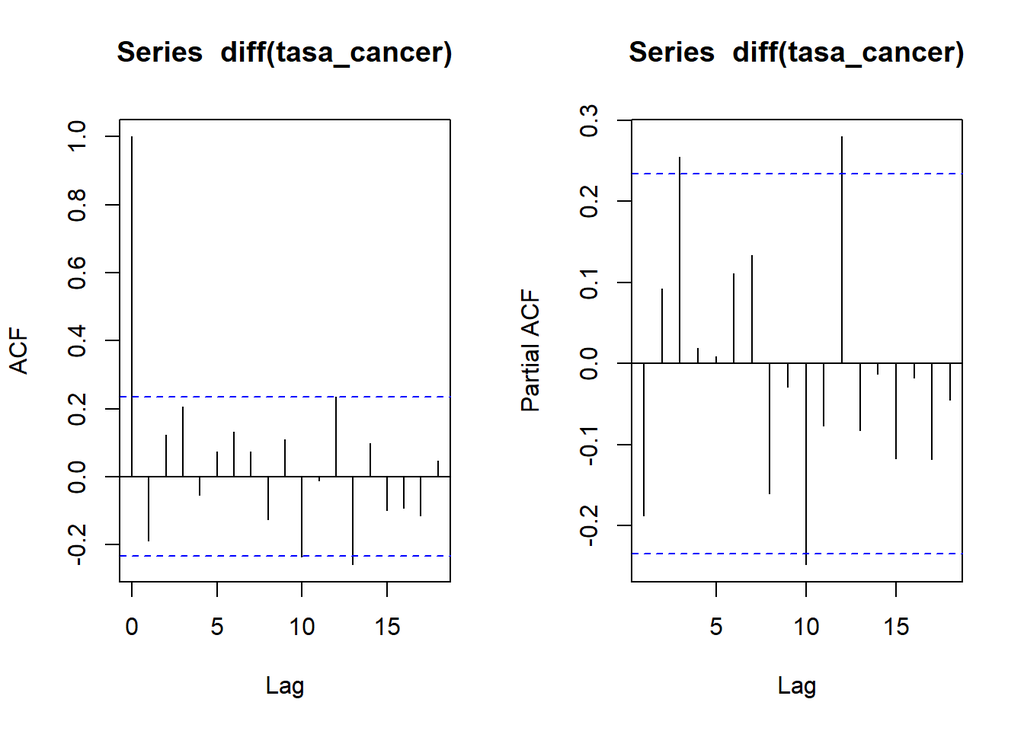

Ajustamos un mejor modelo, la cual es el siguiente:

```r
tcanc_md_1 <- Arima(tasa_cancer,order = c(0,1,0),include.drift = T,method = "CSS-ML")
tcanc_md_1
```

```
## Series: tasa_cancer
## ARIMA(0,1,0) with drift
##
## Coefficients:
##        drift
##       2.0543
## s.e.  0.3312
##
## sigma^2 estimated as 7.789:  log likelihood=-170.67
## AIC=345.33   AICc=345.51   BIC=349.83
```

[interactive chart not shown]

En esta gráfica, observamos que el modelo tiene un sobre ajuste, pues los ocho valores pronosticados están por encima del los valores reales es decir los actuales. Miremos sus puntajes de pronósticos.

Puntajes de pronósticos

|  | ME | RMSE | MAE | MPE | MAPE | MASE | ACF1 | Theil’s U |
| --- | --- | --- | --- | --- | --- | --- | --- | --- |
| Training set | 0.001555 | 2.473387 | 1.918094 | 0.0068277 | 1.115738 | 0.6938262 | -0.2906274 | NA |
| Test set | -13.272177 | 14.944917 | 13.272177 | -5.3457272 | 5.345727 | 4.8009043 | 0.4415682 | 4.764589 |

##### b) Explore la función HoltWinters() para realizar un pronóstico de las mismas observaciones, utilizando EWMA, es decir una media movil exponencialmente ponderada o más breve suavizamiento exponencial. Que valor de $\lambda$ encuentra que es el más adecuado para su conjunto de datos?.